# TO414 - Winter 2021 - Homework Assignment #1

Riley Maher

1/31/2021

## Titanic Data Exploration

For this homework submission, you are asked to explore passenger survival data for the Titanic.

### Specific Questions

Specifically, you are asked to provide answers to the following questions:

1. How deadly was the event? (2 points)
2. Did they make an effort to save women and children first? (2 points)
3. Did the passengers who were in higher fare class survive at higher rates? (2 points)
4. Open Ended: What other conclusions can you draw about survival of passengers aboard the Titanic? (4 points)

### Submission Format

Please submit one RMarkdown document that has your source code and an HTML document that is the output from the RMD document.

In your submission, please do *not* respond with bare R output only. Please make sure you provide text interpretation and explanation of R outputs. Be sure to include ample comments in your R script file.

Please note that the look and feel of your submission **matters**. We are building our outputs to be persuasive to a non-technical audience (*likely your boss in your next job*). You can’t just show up with a bunch of code - they need to be well explained and output needs to be well interpreted for your audience.

### Resources Provided

- The data file for this HW is posted along with this file. Look for `titanic.csv`
- You would want to look through bunch of sample code provided in the R Script file named: `TO414_Lab_Titanic.R`. The script has much more code than you need for this homework - use the file to explore different ways of working with the Titanic data.
- The class presentation files for Wed 09/02 and Mon 09/07 classes has bunch of code and helpful hints that may prove useful to you as well.

## Assignment Submission Policies

Please note the following submission policies and keep them in mind as you work on your assignments.

### Late Submission

Submissions will remain open for 1 week after the submission deadline. However, for each full day of delay, you will lose 1 point as late submission penalty. Minor delays (few minutes) will be ignored.

### Student Collaboration

While you are expected to do this assignment as an individual, it is okay if two people decide to work together and collaborate. If you do decide to collaborate with someone then please clearly identify in your submission who you worked with. Note that you should have full understanding of your submission even if the submission was created in collaboration.

> This HW assignment is due EoD Sun 09/13.

# Homework 1

## Importing Packages

```r
library(dplyr)
```

## Loading Data Set

```r
titanic <- read.csv("titanic.csv", stringsAsFactors = TRUE)
```

## Viewing Data Set

```r
head(titanic)
```

```
##   PassengerId Survived Pclass
## 1           1        0      3
## 2           2        1      1
## 3           3        1      3
## 4           4        1      1
## 5           5        0      3
## 6           6        0      3
##                                                  Name    Sex Age SibSp Parch
## 1                             Braund, Mr. Owen Harris   male  22     1     0
## 2 Cumings, Mrs. John Bradley (Florence Briggs Thayer) female  38     1     0
## 3                              Heikkinen, Miss. Laina female  26     0     0
## 4        Futrelle, Mrs. Jacques Heath (Lily May Peel) female  35     1     0
## 5                            Allen, Mr. William Henry   male  35     0     0
## 6                                    Moran, Mr. James   male  NA     0     0
##             Ticket    Fare Cabin Embarked
## 1        A/5 21171  7.2500              S
## 2         PC 17599 71.2833   C85        C
## 3 STON/O2. 3101282  7.9250              S
## 4           113803 53.1000  C123        S
## 5           373450  8.0500              S
## 6           330877  8.4583              Q
```

```r
str(titanic)
```

```
## 'data.frame':    891 obs. of  12 variables:
##  $ PassengerId: int  1 2 3 4 5 6 7 8 9 10 ...
##  $ Survived   : int  0 1 1 1 0 0 0 0 1 1 ...
##  $ Pclass     : int  3 1 3 1 3 3 1 3 3 2 ...
##  $ Name       : Factor w/ 891 levels "Abbing, Mr. Anthony",..: 109 191 358 277 16 559 520 629 417 581 ...
##  $ Sex        : Factor w/ 2 levels "female","male": 2 1 1 1 2 2 2 2 1 1 ...
##  $ Age        : num  22 38 26 35 35 NA 54 2 27 14 ...
##  $ SibSp      : int  1 1 0 1 0 0 0 3 0 1 ...
##  $ Parch      : int  0 0 0 0 0 0 0 1 2 0 ...
##  $ Ticket     : Factor w/ 681 levels "110152","110413",..: 524 597 670 50 473 276 86 396 345 133 ...
##  $ Fare       : num  7.25 71.28 7.92 53.1 8.05 ...
##  $ Cabin      : Factor w/ 148 levels "","A10","A14",..: 1 83 1 57 1 1 131 1 1 1 ...
##  $ Embarked   : Factor w/ 4 levels "","C","Q","S": 4 2 4 4 4 3 4 4 4 2 ...
```

## How deadly was the event? (2 points)

```r
# Finding the proportion of survivors on Titanic

dead_or_not <- round(prop.table(table(titanic$Survived)), digits = 3)
dead_percent <- dead_or_not[1] * 100
dead_or_not
```

```
##
##     0     1
## 0.616 0.384
```

From the table above, we can see the majority of people who were on the Titanic died. In fact 61.6% of the passengers on the Titanic died.

## Did they make an effort to save women and children first? (2 points)

```r
# Creating a new column to identify kids

titanic$Child <- 0
titanic$Child[titanic$Age<18] <- 1

# Finding survival based on sex

sex_table <- round(prop.table(table(titanic$Sex, titanic$Survived), 1), digits = 3)
female_percent_alive <- sex_table[1, 2] * 100
male_percent_alive <- sex_table[2, 2] * 100

# Finding survival based on age

age_table <- round(prop.table(table(titanic$Child, titanic$Survived), 1), digits = 3)
adult_percent_alive <- age_table[1, 2] * 100
child_percent_alive <- age_table[2, 2] * 100

sex_table
```

```
##
##              0     1
##   female 0.258 0.742
##   male   0.811 0.189
```

```r
age_table
```

```
##
##         0     1
##   0 0.639 0.361
##   1 0.460 0.540
```

## Did the passengers who were in higher fare class survive at higher rates? (2 points)

```r
# Creating a new fare column to classify richer passengers

titanic$Fare2<-"30+" #default
titanic$Fare2[titanic$Fare < 30 & titanic$Fare >= 20] <- "20-30"
titanic$Fare2[titanic$Fare < 20 & titanic$Fare >= 10] <- "10-20"
titanic$Fare2[titanic$Fare < 10] <- "<10"

# Aggregating the the fare data with sex

breakdown2 <- aggregate(Survived ~ Fare2 + Sex, data=titanic, mean)
breakdown2
```

```
##   Fare2    Sex  Survived
## 1   <10 female 0.5937500
## 2 10-20 female 0.7307692
## 3 20-30 female 0.6842105
## 4   30+ female 0.8608696
## 5   <10   male 0.1066176
## 6 10-20   male 0.1881188
## 7 20-30   male 0.2405063
## 8   30+   male 0.3360000
```

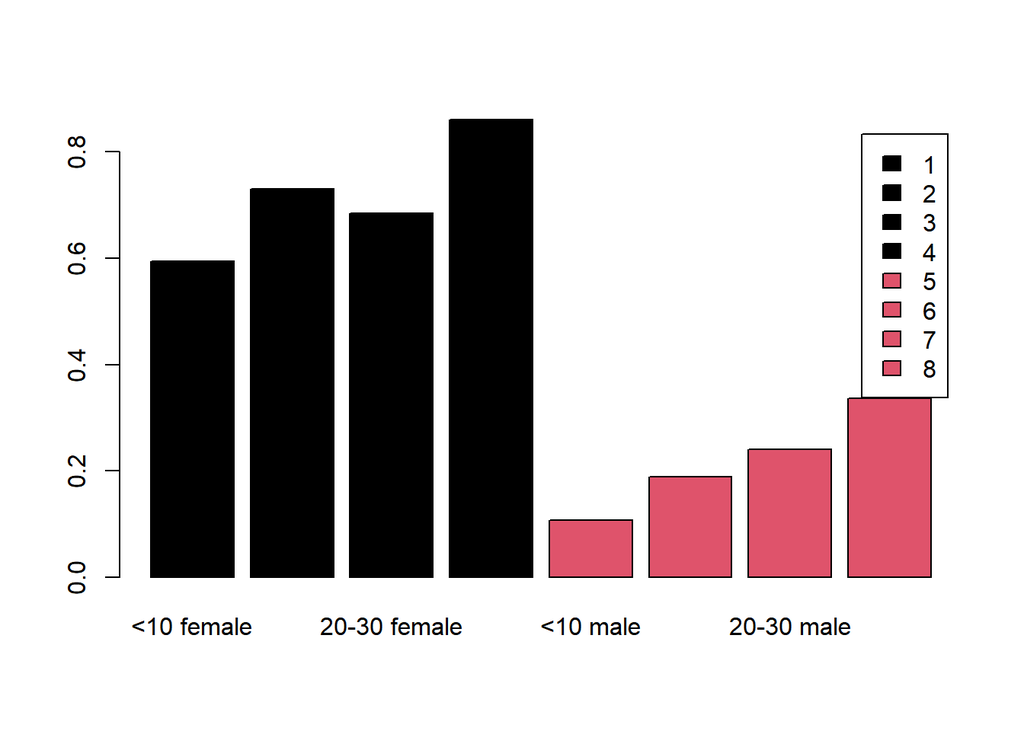

```r
# Bar plot showing data

barplot(breakdown2$Survived,
        col=breakdown2$Sex,
        legend=rownames(breakdown2),
        names.arg=paste(breakdown2$Fare2,
                        breakdown2$Sex))
```

From the bar plot, we can overwhelmingly see that women of all passengers types survived more than men. It does seem that the more you paid for your ticket, the more likely you were to survive, inferring that the Titanic crew prioritized the richer passengers over the poorer ones.

## Open Ended: What other conclusions can you draw about survival of passengers aboard the Titanic?

```r
# Average and median age of all passengers who survived

titanic_survive <- filter(titanic, Survived == 1)
titanic_surive_mean <- round(mean(titanic_survive$Age, na.rm = TRUE), 2)
titanic_surive_median <- round(median(titanic_survive$Age, na.rm = TRUE), 2)
titanic_surive_mean
```

```
## [1] 28.34
```

```r
titanic_surive_median
```

```
## [1] 28
```

```r
# Average and median age of all female passengers who survived

titanic_survive_female <- filter(titanic, Survived == 1 & Sex == "female")
titanic_surive_female_mean <- round(mean(titanic_survive_female$Age, na.rm = TRUE), 2)
titanic_surive_female_median <- round(median(titanic_survive_female$Age, na.rm = TRUE), 2)
titanic_surive_female_mean
```

```
## [1] 28.85
```

```r
titanic_surive_female_median
```

```
## [1] 28
```

```r
# Average and median age of all male passengers who survived

titanic_survive_male <- filter(titanic, Survived == 1 & Sex == "male")
titanic_surive_male_mean <- round(mean(titanic_survive_male$Age, na.rm = TRUE), 2)
titanic_surive_male_median <- round(median(titanic_survive_male$Age, na.rm = TRUE), 2)
titanic_surive_male_mean
```

```
## [1] 27.28
```

```r
titanic_surive_male_median
```

```
## [1] 28
```

```r
# Average and median age of all dead passengers

titanic_dead <- filter(titanic, Survived == 0)
titanic_dead_mean <- round(mean(titanic_dead$Age, na.rm = TRUE), 2)
titanic_dead_median <- round(median(titanic_dead$Age, na.rm = TRUE), 2)
titanic_dead_mean
```

```
## [1] 30.63
```

```r
titanic_dead_median
```

```
## [1] 28
```

```r
# Average and median age of all dead female passengers

titanic_dead_female <- filter(titanic, Survived == 0 & Sex == "female")
titanic_dead_female_mean <- round(mean(titanic_dead_female$Age, na.rm = TRUE), 2)
titanic_dead_female_median <- round(median(titanic_dead_female$Age, na.rm = TRUE), 2)
titanic_dead_female_mean
```

```
## [1] 25.05
```

```r
titanic_dead_female_median
```

```
## [1] 24.5
```

```r
# Average and median age of all dead male passengers

titanic_dead_male <- filter(titanic, Survived == 0 & Sex == "male")
titanic_dead_male_mean <- round(mean(titanic_dead_male$Age, na.rm = TRUE), 2)
titanic_dead_male_median <- round(median(titanic_dead_male$Age, na.rm = TRUE), 2)
titanic_dead_male_mean
```

```
## [1] 31.62
```

```r
titanic_dead_male_median
```

```
## [1] 29
```

```r
# Average and median age of all passengers

titanic_avg_age <- round(mean(titanic$Age, na.rm = TRUE), 2)
titanic_median_age <- round(median(titanic$Age, na.rm = TRUE), 2)

titanic_avg_age
```

```
## [1] 29.7
```

```r
titanic_median_age
```

```
## [1] 28
```

```r
# Proportion of adults with kids who lived/died

kids_table <- round(prop.table(table(titanic$Parch, titanic$Survived), 1), digits = 3)
kids_table
```

```
##
##         0     1
##   0 0.656 0.344
##   1 0.449 0.551
##   2 0.500 0.500
##   3 0.400 0.600
##   4 1.000 0.000
##   5 0.800 0.200
##   6 1.000 0.000
```

Finally, I was curious how having kids affected a person’s survival. It seems that has the number of kids went up to three, the survival rate of the parent went up, but as the number of kids went from three to six, we saw the survival rate of parents mostly go to zero. I’d infer that the adults with more kids were giving up their seats on the lifeboats to ensure that their kids had enough space, causing them to die in the process. As for the increasing survival rate for people with three kids, I assume that’s because they wanted to make sure most children didn’t end up orphans.